# Text Mining Alice in Wonderland

Samuel Johnson

2022-09-05

## Alice in Wonderland text mining

This project is to demonstrate some of what I have learned from David Robinson and Julia Silge’s book on Text mining with a tidy approach.

## Data, libraries, and tidying up

To begin with this project, we first have to call all of the libraries and packages used. The first package, gutenbergr, will mainly be used for downloading Alice. Tidytext is one of the more important texts that will be used. It includes a variety of tools for our textual analysis. Inside of Tidytext, we have a helpful list of words called Stop words. These are common grammatical and functional words that do not heavily impact the semantic meaning and hypersaturate any text. Finally we are going to tidy Alice up by defining the line numbers availabe and then we ungroup the text. Unnest_tokens is a function included with Tidytext that will converta Alice into a 2 X n data frame. The anti_join will remove the Stop words from Alice.

```r
library(gutenbergr)
library(tidyverse)
```

```r
library(tidytext)
library(readr)
library(wordcloud)
library(reshape2)
library(scales)
#Downloading Alice in Wonderland
alice <- gutenberg_download(c(11))
```

```
## Determining mirror for Project Gutenberg from http://www.gutenberg.org/robot/harvest
## Using mirror http://aleph.gutenberg.org
```

```r
#Defining the stop words
data("stop_words")

#Tidying Alice into a 2xn data frame by extracting all tokens
tidy_alice <- alice %>%
  mutate(line_number = row_number()) %>%
  ungroup() %>%
  unnest_tokens(word, text) %>%
  anti_join(stop_words)
```

## Finding frequency

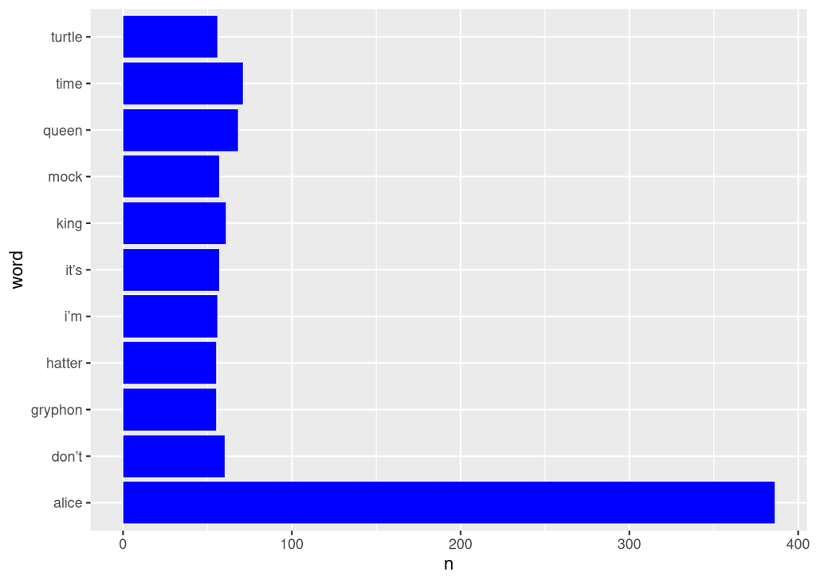

```r
alice_frequency <- tidy_alice %>%
  count(word, sort = TRUE) %>%
  filter(n > 50) %>%
  ggplot(aes(y = word, x = n)) +
  geom_col(fill = "blue")

alice_frequency
```

## Sentiment Analysis

Sentiment Analysis is a way of measuring how a text feels quantitatively. The two datasets we will be using are the NRC dataset and the Bing dataset. The NRC attributes 1 of 8 emotions to each word in a dictionary, for example, joy. We can load this using Tidytext and filter it using dplyr. Next we inner_join the sentiment we are looking for to count the words that correspond to joy in Alice.

```
## # A tibble: 88 × 2
##    word          n
##    <chr>     <int>
##  1 found        32
##  2 garden       15
##  3 baby         14
##  4 beautiful    13
##  5 dance        13
##  6 grow         13
##  7 deal         12
##  8 child        11
##  9 glad         11
## 10 tree          9
## # … with 78 more rows
```

```
## # A tibble: 876 × 4
##    index negative positive sentiment
##    <int>    <dbl>    <dbl>     <dbl>
##  1    19        1        0        -1
##  2    20        1        0        -1
##  3    22        1        0        -1
##  4    24        1        0        -1
##  5    34        1        0        -1
##  6    41        1        2         1
##  7    42        1        1         0
##  8    46        0        1         1
##  9    54        1        0        -1
## 10    55        0        1         1
## # … with 866 more rows
```

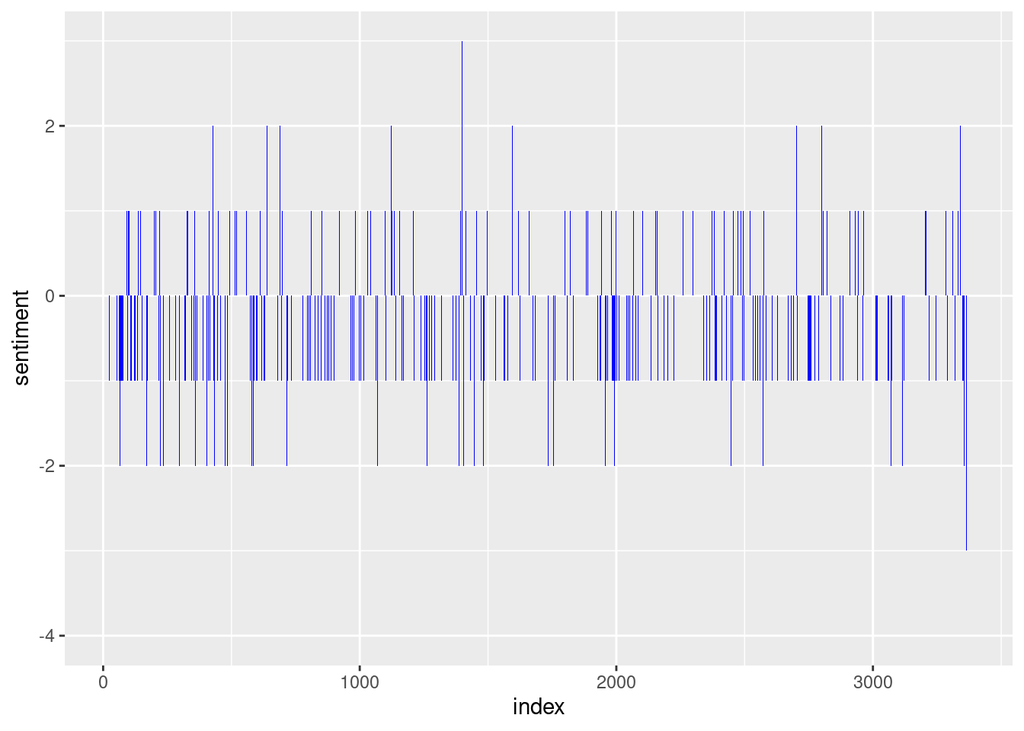

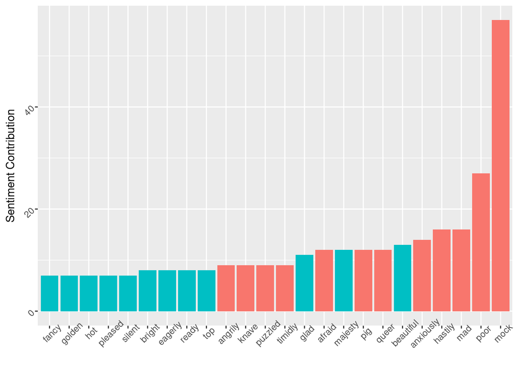

## Wordclouds

Finally the wordclouds will represent the most common words in the text by size. The larger the word, the more frequently it appears throughout the text. For example, “Alice” is the most common word, and therefore the largest.

The second plot maps out the most negative words in green and the positive in orange. This shows us that the Mock Turtle plays an outsized role in the negativity of the text, since he gives us the most common negative word.

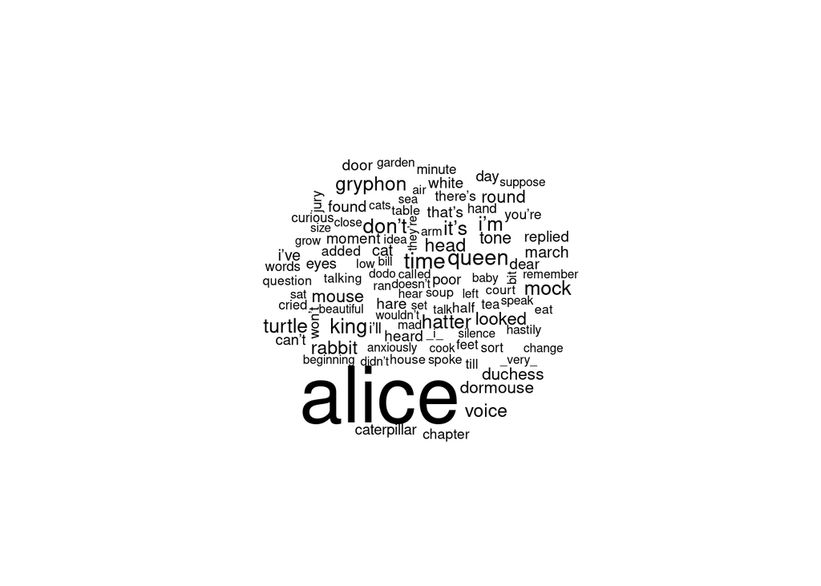

```r
#Alice in Wonderland Wordcloud
#Here we will be working with Word clouds to show frequency and sentiment
tidy_alice %>%
  anti_join(stop_words) %>%
  count(word) %>%
  with(wordcloud(word, n, max.words = 100))
```

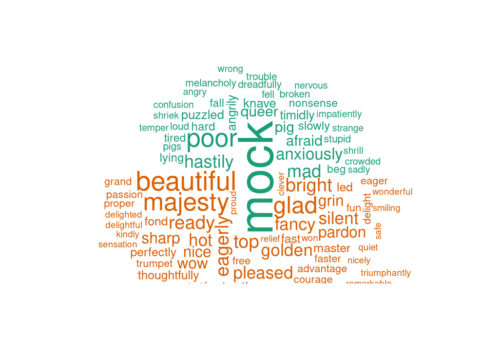

```r
#Sentiment wordcloud
tidy_alice %>%
  inner_join(get_sentiments("bing")) %>%
  count(word, sentiment, sort = TRUE) %>%
  acast(word ~ sentiment, value.var = "n", fill = 0) %>%
  comparison.cloud(max.words = 100)
```